# Stocks Data Analysis using R

Sree Ram Avinash Maddikonda

2022-11-16

```r
library(tidyverse)
library(lubridate)
library(GGally)
```

```r
library(visreg)
library(fastDummies)
library(caTools)
library(ROCR)
library(rpart)
library(rpart.plot)
library(randomForest)
library(patchwork)
library("neuralnet")
df.ko.stock <- read.csv("KO R data.csv", stringsAsFactors= TRUE)
head(df.ko.stock)
```

```
##         Date    KOnextday KOupdown    Kovolume     Kochange Dividendday
## 1 2017-10-31 -0.003914983        0 -0.08905983  0.002616810           0
## 2 2017-11-01  0.001746800        1  0.07729594 -0.003914983           0
## 3 2017-11-02  0.001961451        1  0.17689173  0.001746800           0
## 4 2017-11-03 -0.010876380        0 -0.43129193  0.001961451           0
## 5 2017-11-06  0.010336375        1  0.57519449 -0.010876380           0
## 6 2017-11-07  0.005224199        1  0.32433267  0.010336375           0
##   Dividendminus1wk Dividendminus2wk Dividendminus3wk Dividendplus1wk
## 1                0                0                0               0
## 2                0                0                0               0
## 3                0                0                0               0
## 4                0                0                0               0
## 5                0                0                0               0
## 6                0                0                0               0
##     NYSEchange  Pepsichange KO10dayMA PPIChange    MCDchange
## 1  0.012988663  0.005289529  39.36871     0.002  0.004091038
## 2 -0.007360923 -0.000907137  39.31759     0.002 -0.003235473
## 3  0.007056500 -0.000726599  39.25710     0.002  0.010398307
## 4  0.006650959  0.001544723  39.22216     0.002  0.003271840
## 5 -0.000589931 -0.008709839  39.14974     0.002  0.008419990
## 6 -0.011568817  0.011074421  39.12929     0.002  0.004115954
```

### Variable Descriptions:

#### Dividendday= Independent variable 1 = day dividend was paid, 0= all other days

#### Dividendminus1wk= Independent variable 1= day that was within 1 week before dividend was paid, 0 = all other days

#### Dividendminus2wk= Independent variable 1= day that was within 2 week before dividend was paid, 0 = all other days

#### Dividendminus3wk= Independent variable 1= day that was within 3 week before dividend was paid, 0 = all other days

#### Dividendplus1wk= Independent variable 1= day that was within 1 week after dividend was paid, 0 = all other days

#### NYSEchange= Independent variable NYSE price change

#### Pepsichange= Independent variable Pepsi price change

#### KO10dayMA= Independent variable KO 10 day moving average

#### PPIChange= Independent variable PPI monthly change

#### MCDchange= Independent variable MCD price change

```r
str(df.ko.stock)
```

```
## 'data.frame':    1257 obs. of  15 variables:
##  $ Date            : Factor w/ 1257 levels "2017-10-31","2017-11-01",..: 1 2 3 4 5 6 7 8 9 10 ...
##  $ KOnextday       : num  -0.00391 0.00175 0.00196 -0.01088 0.01034 ...
##  $ KOupdown        : int  0 1 1 0 1 1 1 1 1 1 ...
##  $ Kovolume        : num  -0.0891 0.0773 0.1769 -0.4313 0.5752 ...
##  $ Kochange        : num  0.00262 -0.00391 0.00175 0.00196 -0.01088 ...
##  $ Dividendday     : int  0 0 0 0 0 0 0 0 0 0 ...
##  $ Dividendminus1wk: int  0 0 0 0 0 0 0 0 0 0 ...
##  $ Dividendminus2wk: int  0 0 0 0 0 0 0 0 0 0 ...
##  $ Dividendminus3wk: int  0 0 0 0 0 0 1 1 1 1 ...
##  $ Dividendplus1wk : int  0 0 0 0 0 0 0 0 0 0 ...
##  $ NYSEchange      : num  0.01299 -0.00736 0.00706 0.00665 -0.00059 ...
##  $ Pepsichange     : num  0.00529 -0.000907 -0.000727 0.001545 -0.00871 ...
##  $ KO10dayMA       : num  39.4 39.3 39.3 39.2 39.1 ...
##  $ PPIChange       : num  0.002 0.002 0.002 0.002 0.002 0.002 0.002 0.002 0.002 0.002 ...
##  $ MCDchange       : num  0.00409 -0.00324 0.0104 0.00327 0.00842 ...
```

```r
summary(df.ko.stock)
```

```
##          Date        KOnextday             KOupdown         Kovolume
##  2017-10-31:   1   Min.   :-0.0967248   Min.   :0.0000   Min.   :-0.73600
##  2017-11-01:   1   1st Qu.:-0.0051936   1st Qu.:0.0000   1st Qu.:-0.17120
##  2017-11-02:   1   Median : 0.0008000   Median :1.0000   Median :-0.01403
##  2017-11-03:   1   Mean   : 0.0004415   Mean   :0.5402   Mean   : 0.06057
##  2017-11-06:   1   3rd Qu.: 0.0068198   3rd Qu.:1.0000   3rd Qu.: 0.21251
##  2017-11-07:   1   Max.   : 0.0647957   Max.   :1.0000   Max.   : 4.08319
##  (Other)   :1251
##     Kochange           Dividendday      Dividendminus1wk  Dividendminus2wk
##  Min.   :-0.0967248   Min.   :0.00000   Min.   :0.00000   Min.   :0.00000
##  1st Qu.:-0.0051936   1st Qu.:0.00000   1st Qu.:0.00000   1st Qu.:0.00000
##  Median : 0.0008000   Median :0.00000   Median :0.00000   Median :0.00000
##  Mean   : 0.0004271   Mean   :0.01591   Mean   :0.07955   Mean   :0.07955
##  3rd Qu.: 0.0068014   3rd Qu.:0.00000   3rd Qu.:0.00000   3rd Qu.:0.00000
##  Max.   : 0.0647957   Max.   :1.00000   Max.   :1.00000   Max.   :1.00000
##
##  Dividendminus3wk  Dividendplus1wk     NYSEchange          Pepsichange
##  Min.   :0.00000   Min.   :0.00000   Min.   :-0.0818299   Min.   :-0.1142832
##  1st Qu.:0.00000   1st Qu.:0.00000   1st Qu.:-0.0059070   1st Qu.:-0.0051144
##  Median :0.00000   Median :0.00000   Median : 0.0006817   Median : 0.0008188
##  Mean   :0.07955   Mean   :0.07955   Mean   : 0.0003461   Mean   : 0.0006036
##  3rd Qu.:0.00000   3rd Qu.:0.00000   3rd Qu.: 0.0066510   3rd Qu.: 0.0068201
##  Max.   :1.00000   Max.   :1.00000   Max.   : 0.0587534   Max.   : 0.1293659
##
##    KO10dayMA       PPIChange           MCDchange
##  Min.   :36.36   Min.   :-0.048000   Min.   :-0.1587534
##  1st Qu.:41.76   1st Qu.:-0.003000   1st Qu.:-0.0054064
##  Median :47.58   Median : 0.002000   Median : 0.0006695
##  Mean   :48.16   Mean   : 0.004015   Mean   : 0.0005793
##  3rd Qu.:53.13   3rd Qu.: 0.013000   3rd Qu.: 0.0071388
##  Max.   :64.53   Max.   : 0.053000   Max.   : 0.1812544
##
```

```r
df.ko.stock$Date2 <- ymd(df.ko.stock$Date)
df.ko.stock$month <- month(df.ko.stock$Date2)

df.ko.stock <- df.ko.stock %>% relocate(Date2,month)
#head(df.ko.stock)
```

```r
df.ko.stock <- dummy_cols(df.ko.stock, select_columns=c('month'), remove_selected_columns = TRUE)

df.ko.stock2 <- df.ko.stock %>% subset(select=-c(Date, Date2, month_1))

df.ko.stock2 <- na.omit(df.ko.stock2) # to solve/handle the null values
head(df.ko.stock2)
```

```
##      KOnextday KOupdown    Kovolume     Kochange Dividendday Dividendminus1wk
## 1 -0.003914983        0 -0.08905983  0.002616810           0                0
## 2  0.001746800        1  0.07729594 -0.003914983           0                0
## 3  0.001961451        1  0.17689173  0.001746800           0                0
## 4 -0.010876380        0 -0.43129193  0.001961451           0                0
## 5  0.010336375        1  0.57519449 -0.010876380           0                0
## 6  0.005224199        1  0.32433267  0.010336375           0                0
##   Dividendminus2wk Dividendminus3wk Dividendplus1wk   NYSEchange  Pepsichange
## 1                0                0               0  0.012988663  0.005289529
## 2                0                0               0 -0.007360923 -0.000907137
## 3                0                0               0  0.007056500 -0.000726599
## 4                0                0               0  0.006650959  0.001544723
## 5                0                0               0 -0.000589931 -0.008709839
## 6                0                0               0 -0.011568817  0.011074421
##   KO10dayMA PPIChange    MCDchange month_2 month_3 month_4 month_5 month_6
## 1  39.36871     0.002  0.004091038       0       0       0       0       0
## 2  39.31759     0.002 -0.003235473       0       0       0       0       0
## 3  39.25710     0.002  0.010398307       0       0       0       0       0
## 4  39.22216     0.002  0.003271840       0       0       0       0       0
## 5  39.14974     0.002  0.008419990       0       0       0       0       0
## 6  39.12929     0.002  0.004115954       0       0       0       0       0
##   month_7 month_8 month_9 month_10 month_11 month_12
## 1       0       0       0        1        0        0
## 2       0       0       0        0        1        0
## 3       0       0       0        0        1        0
## 4       0       0       0        0        1        0
## 5       0       0       0        0        1        0
## 6       0       0       0        0        1        0
```

```r
nrow(df.ko.stock)
```

```
## [1] 1257
```

```r
nrow(df.ko.stock2)
```

```
## [1] 1257
```

### Linear Regression Model:

```r
linear.reg.model = lm(KOnextday ~.-KOupdown, data=df.ko.stock2)
summary(linear.reg.model)
```

```
##
## Call:
## lm(formula = KOnextday ~ . - KOupdown, data = df.ko.stock2)
##
## Residuals:
##       Min        1Q    Median        3Q       Max
## -0.096564 -0.005740  0.000386  0.006395  0.062913
##
## Coefficients:
##                    Estimate Std. Error t value Pr(>|t|)
## (Intercept)       4.302e-03  2.863e-03   1.503   0.1331
## Kovolume         -1.468e-04  9.359e-04  -0.157   0.8754
## Kochange          3.881e-02  4.446e-02   0.873   0.3829
## Dividendday       1.231e-03  3.212e-03   0.383   0.7016
## Dividendminus1wk -4.062e-03  1.719e-03  -2.363   0.0183 *
## Dividendminus2wk  5.005e-04  1.619e-03   0.309   0.7573
## Dividendminus3wk -2.106e-04  1.591e-03  -0.132   0.8947
## Dividendplus1wk  -3.029e-03  1.669e-03  -1.816   0.0697 .
## NYSEchange       -3.362e-02  4.150e-02  -0.810   0.4181
## Pepsichange      -6.942e-02  4.464e-02  -1.555   0.1202
## KO10dayMA        -7.399e-05  5.354e-05  -1.382   0.1673
## PPIChange         1.055e-02  3.239e-02   0.326   0.7448
## MCDchange        -1.917e-02  3.189e-02  -0.601   0.5479
## month_2          -2.371e-03  1.985e-03  -1.195   0.2324
## month_3          -5.247e-04  2.053e-03  -0.256   0.7983
## month_4           9.799e-04  1.891e-03   0.518   0.6044
## month_5          -7.813e-05  1.957e-03  -0.040   0.9682
## month_6           1.417e-03  2.115e-03   0.670   0.5031
## month_7           9.502e-04  1.884e-03   0.504   0.6141
## month_8          -1.133e-04  1.911e-03  -0.059   0.9527
## month_9          -3.803e-05  2.087e-03  -0.018   0.9855
## month_10          5.578e-04  1.867e-03   0.299   0.7651
## month_11          9.179e-04  2.090e-03   0.439   0.6606
## month_12          9.518e-04  1.932e-03   0.493   0.6223
## ---
## Signif. codes:  0 '***' 0.001 '**' 0.01 '*' 0.05 '.' 0.1 ' ' 1
##
## Residual standard error: 0.01353 on 1233 degrees of freedom
## Multiple R-squared:  0.01987,    Adjusted R-squared:  0.001583
## F-statistic: 1.087 on 23 and 1233 DF,  p-value: 0.3528
```

### Logistic Regression Model:

```r
logistic.reg.model = glm(KOupdown ~.-KOnextday, data=df.ko.stock2, family="binomial")
summary(logistic.reg.model)
```

```
##
## Call:
## glm(formula = KOupdown ~ . - KOnextday, family = "binomial",
##     data = df.ko.stock2)
##
## Deviance Residuals:
##     Min       1Q   Median       3Q      Max
## -1.6927  -1.2346   0.9758   1.0936   1.5235
##
## Coefficients:
##                   Estimate Std. Error z value Pr(>|z|)
## (Intercept)      -0.028717   0.427636  -0.067    0.946
## Kovolume         -0.084395   0.140574  -0.600    0.548
## Kochange         -3.172070   6.653104  -0.477    0.634
## Dividendday       0.612759   0.514598   1.191    0.234
## Dividendminus1wk -0.322849   0.255831  -1.262    0.207
## Dividendminus2wk  0.031286   0.241894   0.129    0.897
## Dividendminus3wk -0.196447   0.237444  -0.827    0.408
## Dividendplus1wk  -0.270243   0.248337  -1.088    0.277
## NYSEchange       -5.647414   6.214182  -0.909    0.363
## Pepsichange       2.433444   6.695020   0.363    0.716
## KO10dayMA         0.007043   0.008002   0.880    0.379
## PPIChange        -5.477448   4.861736  -1.127    0.260
## MCDchange        -3.139017   4.791302  -0.655    0.512
## month_2          -0.119500   0.295708  -0.404    0.686
## month_3           0.015391   0.306894   0.050    0.960
## month_4           0.038371   0.282931   0.136    0.892
## month_5          -0.420114   0.291910  -1.439    0.150
## month_6          -0.215797   0.315495  -0.684    0.494
## month_7          -0.210874   0.280262  -0.752    0.452
## month_8          -0.066767   0.285000  -0.234    0.815
## month_9          -0.161683   0.311053  -0.520    0.603
## month_10          0.052100   0.279274   0.187    0.852
## month_11          0.130650   0.313003   0.417    0.676
## month_12          0.162144   0.290364   0.558    0.577
##
## (Dispersion parameter for binomial family taken to be 1)
##
##     Null deviance: 1734.4  on 1256  degrees of freedom
## Residual deviance: 1714.9  on 1233  degrees of freedom
## AIC: 1762.9
##
## Number of Fisher Scoring iterations: 4
```

```r
coef(logistic.reg.model)
```

```
##      (Intercept)         Kovolume         Kochange      Dividendday
##     -0.028717015     -0.084395096     -3.172070184      0.612758975
## Dividendminus1wk Dividendminus2wk Dividendminus3wk  Dividendplus1wk
##     -0.322848729      0.031285926     -0.196446621     -0.270242921
##       NYSEchange      Pepsichange        KO10dayMA        PPIChange
##     -5.647413872      2.433444306      0.007043108     -5.477447832
##        MCDchange          month_2          month_3          month_4
##     -3.139016736     -0.119499722      0.015390853      0.038370528
##          month_5          month_6          month_7          month_8
##     -0.420114171     -0.215796542     -0.210874450     -0.066767456
##          month_9         month_10         month_11         month_12
##     -0.161683121      0.052099523      0.130650409      0.162143730
```

```r
exp(coef(logistic.reg.model))
```

```
##      (Intercept)         Kovolume         Kochange      Dividendday
##      0.971691400      0.919068065      0.041916733      1.845516115
## Dividendminus1wk Dividendminus2wk Dividendminus3wk  Dividendplus1wk
##      0.724083379      1.031780475      0.821645189      0.763194076
##       NYSEchange      Pepsichange        KO10dayMA        PPIChange
##      0.003526625     11.398073000      1.007067969      0.004179984
##        MCDchange          month_2          month_3          month_4
##      0.043325377      0.887364254      1.015509902      1.039116183
##          month_5          month_6          month_7          month_8
##      0.656971809      0.805899252      0.809875741      0.935412700
##          month_9         month_10         month_11         month_12
##      0.850710734      1.053480583      1.139569329      1.176029260
```

```r
coeftable <- data.frame(col1=coef(logistic.reg.model),col2=exp(coef(logistic.reg.model)))
colnames(coeftable)<-c('Coefficient (log-odds)','e^coefficient (odds)')
coeftable
```

```
##                  Coefficient (log-odds) e^coefficient (odds)
## (Intercept)                -0.028717015          0.971691400
## Kovolume                   -0.084395096          0.919068065
## Kochange                   -3.172070184          0.041916733
## Dividendday                 0.612758975          1.845516115
## Dividendminus1wk           -0.322848729          0.724083379
## Dividendminus2wk            0.031285926          1.031780475
## Dividendminus3wk           -0.196446621          0.821645189
## Dividendplus1wk            -0.270242921          0.763194076
## NYSEchange                 -5.647413872          0.003526625
## Pepsichange                 2.433444306         11.398073000
## KO10dayMA                   0.007043108          1.007067969
## PPIChange                  -5.477447832          0.004179984
## MCDchange                  -3.139016736          0.043325377
## month_2                    -0.119499722          0.887364254
## month_3                     0.015390853          1.015509902
## month_4                     0.038370528          1.039116183
## month_5                    -0.420114171          0.656971809
## month_6                    -0.215796542          0.805899252
## month_7                    -0.210874450          0.809875741
## month_8                    -0.066767456          0.935412700
## month_9                    -0.161683121          0.850710734
## month_10                    0.052099523          1.053480583
## month_11                    0.130650409          1.139569329
## month_12                    0.162143730          1.176029260
```

#### Confusion Matrix

Define a threshold and make predictions for default:

```r
#The threshold is the value above which Y will be classified as 1 and below or equal  Y will be classified as 0.
threshold1 = 0.25
threshold2 = 0.5
threshold3 = 0.6
threshold4 = 0.7
threshold5 = 0.75
df.ko.stock2$predProbs = predict(logistic.reg.model, newdata=df.ko.stock2, type="response")
df.ko.stock2$pred.price.change.th1 = ifelse(df.ko.stock2$predProbs >= threshold1, 1, 0)
df.ko.stock2$pred.price.change.th2 = ifelse(df.ko.stock2$predProbs >= threshold2, 1, 0)
df.ko.stock2$pred.price.change.th3 = ifelse(df.ko.stock2$predProbs >= threshold3, 1, 0)
df.ko.stock2$pred.price.change.th4 = ifelse(df.ko.stock2$predProbs >= threshold4, 1, 0)
df.ko.stock2$pred.price.change.th5 = ifelse(df.ko.stock2$predProbs >= threshold5, 1, 0)
#head(df.ko.stock2)
```

```r
df.ko.stock2 <- df.ko.stock2 %>%relocate(KOupdown,pred.price.change.th1,pred.price.change.th2,pred.price.change.th3,pred.price.change.th4,pred.price.change.th5, predProbs)
#head(df.ko.stock2)
```

**Now we can compare actual defaults vs predicted.**

```r
ConfMatrix1 <- table(df.ko.stock2$KOupdown, df.ko.stock2$pred.price.change.th1)
ConfMatrix2 <- table(df.ko.stock2$KOupdown, df.ko.stock2$pred.price.change.th2)
ConfMatrix3 <- table(df.ko.stock2$KOupdown, df.ko.stock2$pred.price.change.th3)
ConfMatrix4 <- table(df.ko.stock2$KOupdown, df.ko.stock2$pred.price.change.th4)
ConfMatrix5 <- table(df.ko.stock2$KOupdown, df.ko.stock2$pred.price.change.th5)

colnames(ConfMatrix2)<-c("Pred False", "Pred True")
rownames(ConfMatrix2)<-c("Obs False", "Obs True")
colnames(ConfMatrix3)<-c("Pred False", "Pred True")
rownames(ConfMatrix3)<-c("Obs False", "Obs True")
colnames(ConfMatrix4)<-c("Pred False", "Pred True")
rownames(ConfMatrix4)<-c("Obs False", "Obs True")
colnames(ConfMatrix5)<-c("Pred False", "Pred True")
rownames(ConfMatrix5)<-c("Obs False", "Obs True")

print("For Threshold 1 - 0.25")
```

```
## [1] "For Threshold 1 - 0.25"
```

```r
ConfMatrix1
```

```
##
##       1
##   0 578
##   1 679
```

```r
writeLines("")
```

```r
print("For Threshold 2 - 0.5")
```

```
## [1] "For Threshold 2 - 0.5"
```

```r
ConfMatrix2
```

```
##
##             Pred False Pred True
##   Obs False        159       419
##   Obs True         126       553
```

```r
writeLines("")
```

```r
print("For Threshold 3 - 0.6")
```

```
## [1] "For Threshold 3 - 0.6"
```

```r
ConfMatrix3
```

```
##
##             Pred False Pred True
##   Obs False        515        63
##   Obs True         577       102
```

```r
writeLines("")
```

```r
print("For Threshold 4 - 0.7")
```

```
## [1] "For Threshold 4 - 0.7"
```

```r
ConfMatrix4
```

```
##
##             Pred False Pred True
##   Obs False        576         2
##   Obs True         672         7
```

```r
writeLines("")
```

```r
print("For Threshold 5 - 0.75")
```

```
## [1] "For Threshold 5 - 0.75"
```

```r
ConfMatrix5
```

```
##
##             Pred False Pred True
##   Obs False        577         1
##   Obs True         678         1
```

#### Creating the resuable function calculate_metrics - can be used in multiple places

```r
calculate_metrics <- function(predicted,actual){
TN <- sum(df.ko.stock2[,predicted]==0 & df.ko.stock2[,actual]==0)
FN <- sum(df.ko.stock2[,predicted]==0 & df.ko.stock2[,actual]==1)
TP <- sum(df.ko.stock2[,predicted]==1 & df.ko.stock2[,actual]==1)
FP <- sum(df.ko.stock2[,predicted]==1 & df.ko.stock2[,actual]==0)

#Getting Accuracy, Sensitivity and Specificity:

ACCU <- (TN+TP)/(TN+TP+FN+FP)
SENS <- TP/(TP+FN)
SPEC <- TN/(TN+FP)

return (list(accuracy = round(ACCU,4),sensitivity=round(SENS,4),specificity=round(SPEC,4)))
}
```

```r
result.th1 <- calculate_metrics("pred.price.change.th1","KOupdown")
print(paste("Logistic regression model Threshold 1 - 0.25: Accuracy is:",result.th1$accuracy,"Sensitivity is:",result.th1$sensitivity,"Specificity is:",result.th1$specificity))
```

```
## [1] "Logistic regression model Threshold 1 - 0.25: Accuracy is: 0.5402 Sensitivity is: 1 Specificity is: 0"
```

```r
result.th2 <- calculate_metrics("pred.price.change.th2","KOupdown")
print(paste("Logistic regression model Threshold 2 - 0.5: Accuracy is:",result.th2$accuracy,"Sensitivity is:",result.th2$sensitivity,"Specificity is:",result.th2$specificity))
```

```
## [1] "Logistic regression model Threshold 2 - 0.5: Accuracy is: 0.5664 Sensitivity is: 0.8144 Specificity is: 0.2751"
```

```r
result.th3 <- calculate_metrics("pred.price.change.th3","KOupdown")
print(paste("Logistic regression model Threshold 3 - 0.6: Accuracy is:",result.th3$accuracy,"Sensitivity is:",result.th3$sensitivity,"Specificity is:",result.th3$specificity))
```

```
## [1] "Logistic regression model Threshold 3 - 0.6: Accuracy is: 0.4909 Sensitivity is: 0.1502 Specificity is: 0.891"
```

```r
result.th4 <- calculate_metrics("pred.price.change.th4","KOupdown")
print(paste("Logistic regression model Threshold 4 - 0.7: Accuracy is:",result.th4$accuracy,"Sensitivity is:",result.th4$sensitivity,"Specificity is:",result.th4$specificity))
```

```
## [1] "Logistic regression model Threshold 4 - 0.7: Accuracy is: 0.4638 Sensitivity is: 0.0103 Specificity is: 0.9965"
```

```r
result.th5 <- calculate_metrics("pred.price.change.th5","KOupdown")
print(paste("Logistic regression model Threshold 5 - 0.75: Accuracy is:",result.th5$accuracy,"Sensitivity is:",result.th5$sensitivity,"Specificity is:",result.th5$specificity))
```

```
## [1] "Logistic regression model Threshold 5 - 0.75: Accuracy is: 0.4598 Sensitivity is: 0.0015 Specificity is: 0.9983"
```

### Next, Building Regression Tree Model

#### taking fresh dataframe prior to building the regression tree

```r
df.ko.stock3 <- df.ko.stock2 %>% subset(select=-c(KOupdown,pred.price.change.th1,pred.price.change.th2,pred.price.change.th3 ,pred.price.change.th4,pred.price.change.th5,predProbs))
head(df.ko.stock3)
```

```
##      KOnextday    Kovolume     Kochange Dividendday Dividendminus1wk
## 1 -0.003914983 -0.08905983  0.002616810           0                0
## 2  0.001746800  0.07729594 -0.003914983           0                0
## 3  0.001961451  0.17689173  0.001746800           0                0
## 4 -0.010876380 -0.43129193  0.001961451           0                0
## 5  0.010336375  0.57519449 -0.010876380           0                0
## 6  0.005224199  0.32433267  0.010336375           0                0
##   Dividendminus2wk Dividendminus3wk Dividendplus1wk   NYSEchange  Pepsichange
## 1                0                0               0  0.012988663  0.005289529
## 2                0                0               0 -0.007360923 -0.000907137
## 3                0                0               0  0.007056500 -0.000726599
## 4                0                0               0  0.006650959  0.001544723
## 5                0                0               0 -0.000589931 -0.008709839
## 6                0                0               0 -0.011568817  0.011074421
##   KO10dayMA PPIChange    MCDchange month_2 month_3 month_4 month_5 month_6
## 1  39.36871     0.002  0.004091038       0       0       0       0       0
## 2  39.31759     0.002 -0.003235473       0       0       0       0       0
## 3  39.25710     0.002  0.010398307       0       0       0       0       0
## 4  39.22216     0.002  0.003271840       0       0       0       0       0
## 5  39.14974     0.002  0.008419990       0       0       0       0       0
## 6  39.12929     0.002  0.004115954       0       0       0       0       0
##   month_7 month_8 month_9 month_10 month_11 month_12
## 1       0       0       0        1        0        0
## 2       0       0       0        0        1        0
## 3       0       0       0        0        1        0
## 4       0       0       0        0        1        0
## 5       0       0       0        0        1        0
## 6       0       0       0        0        1        0
```

#### Splitting Dataset into training and test

We will leave 80% of observations in the training set and 20% in the test set.

```r
#set.seed just keeps results random but constant for all using the same seed (so we all will have the same results)
set.seed(1127, sample.kind = "Rejection")
spl = sample(nrow(df.ko.stock3),0.8*nrow(df.ko.stock3))
head(spl)
```

```
## [1]  242  944 1222   20  826  602
```

```r
# Now lets split our dataset into train and test:
train.df = df.ko.stock3[spl,]
test.df = df.ko.stock3[-spl,]
```

#### Now training the tree

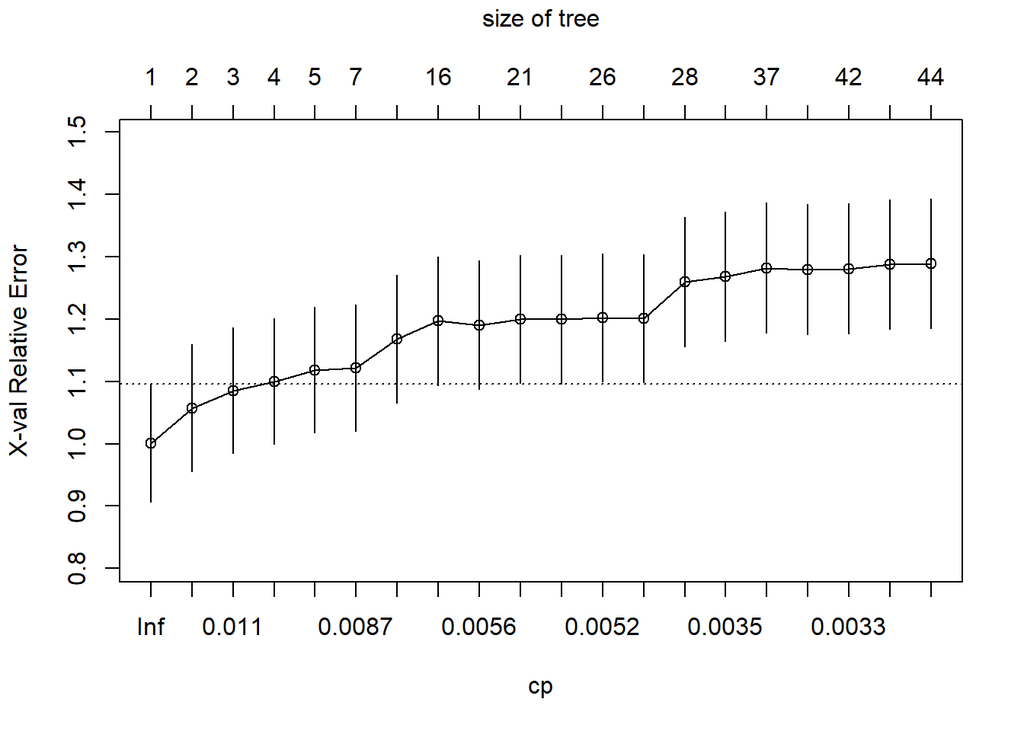

```r
set.seed(1127, sample.kind = "Rejection")
regtree_cv <- rpart(KOnextday ~ ., data=train.df,cp=0.003,method="anova")
plotcp(regtree_cv)
```

#### Now using this cp value to train the tree

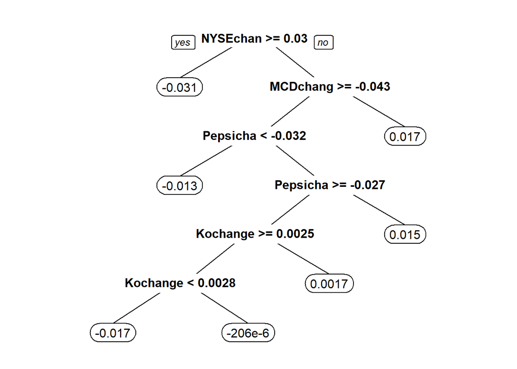

```r
set.seed(1127, sample.kind = "Rejection")
optimal.tree.cv <- rpart(KOnextday ~ ., data=train.df, method="anova",cp=0.009)
prp(optimal.tree.cv)
```

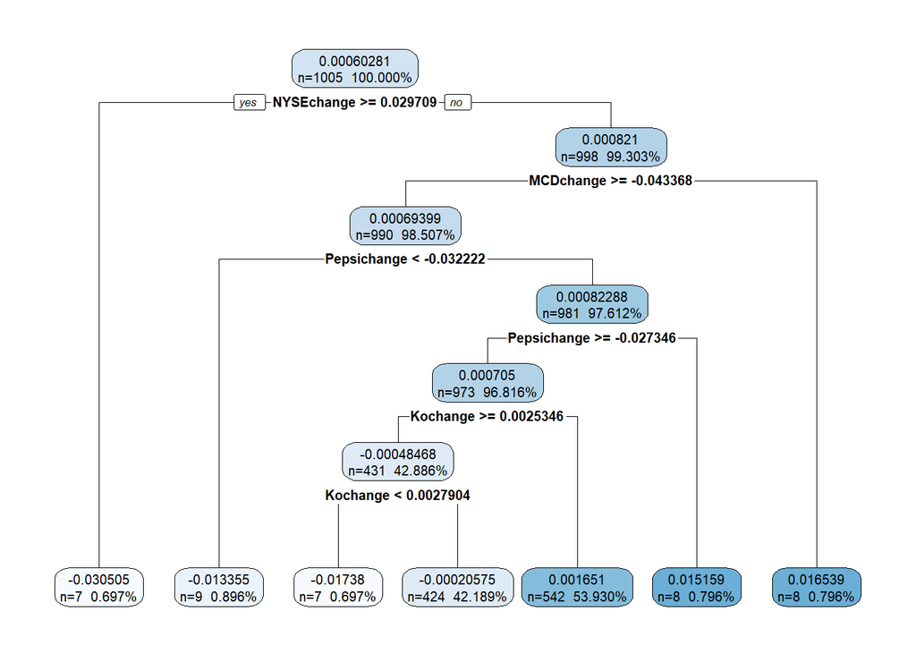

```r
rpart.plot(optimal.tree.cv,digits=-5,extra=101)
```

```r
help(rpart.plot)
```

```
## starting httpd help server ... done
```

#### Lets get predictions for regression models:

```r
test.df$pred.regtree = predict(optimal.tree.cv, newdata = test.df)
head(test.df) %>% relocate(pred.regtree)
```

```
##     pred.regtree    KOnextday    Kovolume     Kochange Dividendday
## 4   0.0016510395 -0.010876380 -0.43129193  0.001961451           0
## 7  -0.0002057461  0.001082966 -0.23116133  0.005224199           0
## 10 -0.0002057461  0.015196728 -0.04603074  0.003867674           0
## 28  0.0016510395  0.000441526  0.45375281 -0.010266686           0
## 32 -0.0002057461  0.003476024 -0.27295127  0.002832156           0
## 36  0.0016510395 -0.010416781 -0.11416178 -0.001083879           0
##    Dividendminus1wk Dividendminus2wk Dividendminus3wk Dividendplus1wk
## 4                 0                0                0               0
## 7                 0                0                1               0
## 10                0                0                1               0
## 28                0                0                0               0
## 32                0                0                0               0
## 36                0                0                0               0
##      NYSEchange  Pepsichange KO10dayMA PPIChange    MCDchange month_2 month_3
## 4   0.006650959  0.001544723  39.22216     0.002  0.003271840       0       0
## 7   0.007524187  0.013850114  39.14037     0.002 -0.003923219       0       0
## 10  0.009279179  0.011441510  39.25369     0.002  0.010749310       0       0
## 28 -0.001276632 -0.001370542  39.33276    -0.002  0.001387839       0       0
## 32 -0.008192010  0.001867540  39.38996    -0.002 -0.002362366       0       0
## 36 -0.009331307  0.003456701  39.34014    -0.002 -0.007036025       0       0
##    month_4 month_5 month_6 month_7 month_8 month_9 month_10 month_11 month_12
## 4        0       0       0       0       0       0        0        1        0
## 7        0       0       0       0       0       0        0        1        0
## 10       0       0       0       0       0       0        0        1        0
## 28       0       0       0       0       0       0        0        0        1
## 32       0       0       0       0       0       0        0        0        1
## 36       0       0       0       0       0       0        0        0        1
```

```r
tail(test.df) %>% relocate(pred.regtree)
```

```
##       pred.regtree    KOnextday    Kovolume     Kochange Dividendday
## 1247 -0.0002057461 -0.015929820 -0.11735610  0.013239028           0
## 1251  0.0016510395 -0.015725465 -0.13877917 -0.008504607           0
## 1254 -0.0002057461  0.023970836  0.15894996  0.028770569           0
## 1255 -0.0002057461  0.007463918  0.65530210  0.023970836           0
## 1256 -0.0002057461  0.002357299 -0.45086872  0.007463918           0
## 1257  0.0016510395  0.020661835  0.01229834  0.002357299           0
##      Dividendminus1wk Dividendminus2wk Dividendminus3wk Dividendplus1wk
## 1247                0                0                0               0
## 1251                0                0                0               0
## 1254                0                0                0               0
## 1255                0                0                0               0
## 1256                0                0                0               0
## 1257                0                0                0               0
##        NYSEchange  Pepsichange KO10dayMA PPIChange   MCDchange month_2 month_3
## 1247 -0.007626372  0.030816471    55.511     0.005 0.040875736       0       0
## 1251 -0.022754500 -0.009710939    55.249     0.005 0.006260275       0       0
## 1254  0.012188219  0.026695915    55.717     0.005 0.003024962       0       0
## 1255  0.014841819  0.003320638    56.164     0.005 0.001605785       0       0
## 1256  0.007174384  0.004487592    56.589     0.005 0.003441086       0       0
## 1257 -0.025662082 -0.001061049    56.955     0.005 0.033124198       0       0
##      month_4 month_5 month_6 month_7 month_8 month_9 month_10 month_11 month_12
## 1247       0       0       0       0       0       0        1        0        0
## 1251       0       0       0       0       0       0        1        0        0
## 1254       0       0       0       0       0       0        1        0        0
## 1255       0       0       0       0       0       0        1        0        0
## 1256       0       0       0       0       0       0        1        0        0
## 1257       0       0       0       0       0       0        1        0        0
```

#### Now, calculating the metrics for regression tree model:

#### To get out of sample R square:

```r
mean_train = mean(train.df$KOnextday)

# Then, we compute the sum of squared errors (SSE) using our tree:

SSE = sum((test.df$KOnextday - test.df$pred.regtree)^2)

SSE
```

```
## [1] 0.06634558
```

```r
print(paste("Regression Tree has a SSE of", round(SSE,4)))
```

```
## [1] "Regression Tree has a SSE of 0.0663"
```

```r
# And the total sum of squared errors (SST) using our simple benchmark model
# (the average mpg in the training set)

SST = sum((test.df$KOnextday - mean_train)^2)

# With that, we finally get

OSR2 = 1 - SSE/SST

OSR2
```

```
## [1] -0.1574756
```

```r
print(paste("Regression Tree has a OSR2 of", round(OSR2,4)))
```

```
## [1] "Regression Tree has a OSR2 of -0.1575"
```

#### MAE for comparisons

```r
MAE = mean(abs(test.df$KOnextday - test.df$pred.regtree))
MAE
```

```
## [1] 0.009445588
```

```r
print(paste("Regression Tree has a MAE of", round(MAE,4)))
```

```
## [1] "Regression Tree has a MAE of 0.0094"
```

### Classification Tree

```r
KOdata = read.csv("KO R data.csv", stringsAsFactors = TRUE)
KOdata$Date<-ymd(KOdata$Date)
KOdata$year<-year(KOdata$Date)
KOdata$month<-month(KOdata$Date)
KOdata2<-dummy_cols(KOdata, select_columns=c('month','Type'), remove_selected_columns = TRUE)
KOdata4 = subset(KOdata2, select = -c(Date,year,month_1) )

head(KOdata4)
```

```
##      KOnextday KOupdown    Kovolume     Kochange Dividendday Dividendminus1wk
## 1 -0.003914983        0 -0.08905983  0.002616810           0                0
## 2  0.001746800        1  0.07729594 -0.003914983           0                0
## 3  0.001961451        1  0.17689173  0.001746800           0                0
## 4 -0.010876380        0 -0.43129193  0.001961451           0                0
## 5  0.010336375        1  0.57519449 -0.010876380           0                0
## 6  0.005224199        1  0.32433267  0.010336375           0                0
##   Dividendminus2wk Dividendminus3wk Dividendplus1wk   NYSEchange  Pepsichange
## 1                0                0               0  0.012988663  0.005289529
## 2                0                0               0 -0.007360923 -0.000907137
## 3                0                0               0  0.007056500 -0.000726599
## 4                0                0               0  0.006650959  0.001544723
## 5                0                0               0 -0.000589931 -0.008709839
## 6                0                0               0 -0.011568817  0.011074421
##   KO10dayMA PPIChange    MCDchange month_2 month_3 month_4 month_5 month_6
## 1  39.36871     0.002  0.004091038       0       0       0       0       0
## 2  39.31759     0.002 -0.003235473       0       0       0       0       0
## 3  39.25710     0.002  0.010398307       0       0       0       0       0
## 4  39.22216     0.002  0.003271840       0       0       0       0       0
## 5  39.14974     0.002  0.008419990       0       0       0       0       0
## 6  39.12929     0.002  0.004115954       0       0       0       0       0
##   month_7 month_8 month_9 month_10 month_11 month_12
## 1       0       0       0        1        0        0
## 2       0       0       0        0        1        0
## 3       0       0       0        0        1        0
## 4       0       0       0        0        1        0
## 5       0       0       0        0        1        0
## 6       0       0       0        0        1        0
```

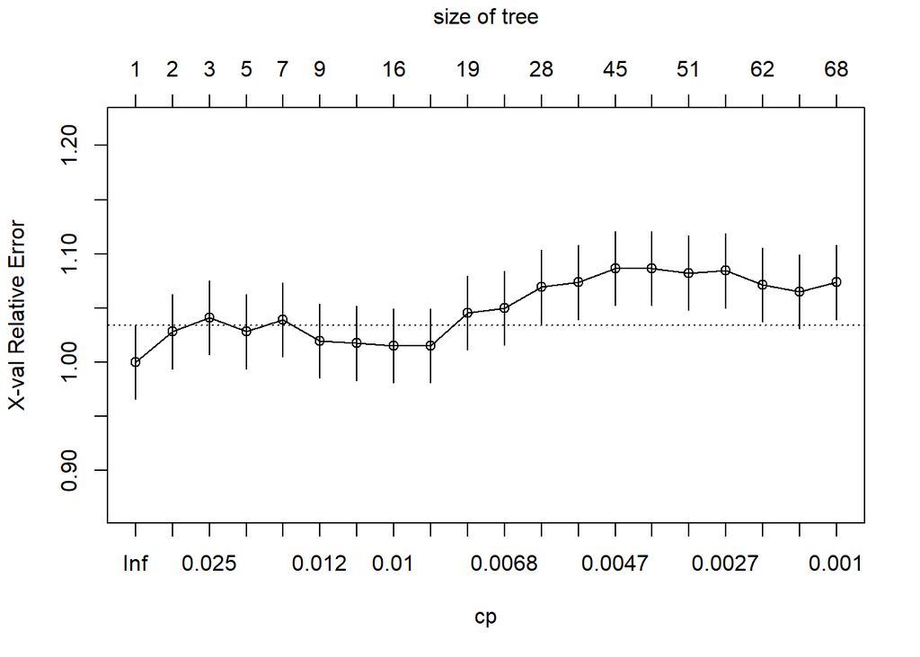

```r
set.seed(5, sample.kind = "Rejection")

#split the dataset leaving 80% of observations in the training dataset and 20% in the test dataset:
spl = sample(nrow(KOdata4),0.8*nrow(KOdata4))
#head(spl)

train.KOdata4 = KOdata4[spl,]
test.KOdata4 = KOdata4[-spl,]

testtree<-rpart(KOupdown ~ .-KOnextday, data=train.KOdata4, method="class",cp=0.001)

plotcp(testtree)
```

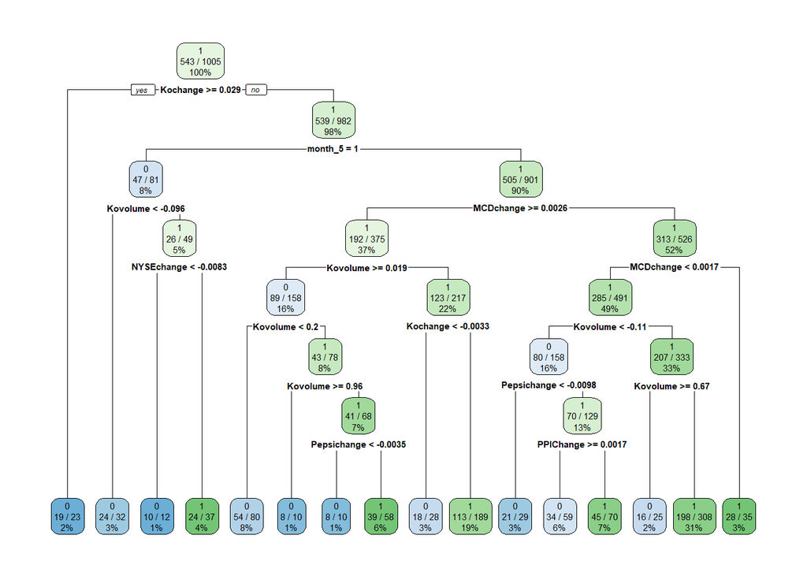

```r
tree<-rpart(KOupdown ~ .-KOnextday, data=train.KOdata4, method="class",cp=0.01)
rpart.plot(tree,extra=102)
```

```r
predT = predict(tree, newdata = test.KOdata4, type="class")
test.KOdata4$predKOupdown2 = predT
test.KOdata4<-test.KOdata4%>%relocate(predKOupdown2)
```

```r
ConfMatrixT<-table(test.KOdata4$KOupdown,test.KOdata4$predKOupdown2)
rownames(ConfMatrixT)<-c("Observed False", "Observed True")
colnames(ConfMatrixT)<-c("Pred False", "Pred True")
ConfMatrixT
```

```
##
##                  Pred False Pred True
##   Observed False         32        84
##   Observed True          49        87
```

For cp=0.01

seed 1= Pred False Pred True Observed False 59 56 =115 Observed True 57 80 =137 =54.4% =58.8%

seed 2= Pred False Pred True Observed False 41 73 =114 Observed True 46 92 =138 =54.8% =55.8% seed 3= Pred False Pred True Observed False 54 66 =120 Observed True 56 76 =132 =52.4% =53.5% seed 4= Pred False Pred True Observed False 41 70 =111 Observed True 58 83 =141 =56.0% =54.2% seed 5= Pred False Pred True Observed False 32 84 =116 Observed True 49 87 =136 =54.0% =50.9%

For cp = 0.001

seed 1= Pred False Pred True Observed False 68 47  
Observed True 67 70 =54.4% =59.8% seed 2= Pred False Pred True Observed False 55 59 Observed True 60 78 =54.8% =56.9% seed 3= Pred False Pred True Observed False 65 55 Observed True 59 73 =52.4% =57.0% seed 4= Pred False Pred True Observed False 45 66 Observed True 64 77 =56.0% =53.8% seed 5= Pred False Pred True Observed False 53 63 Observed True 64 72 =54.0% =53.3%

cp=0.001 seems to perform better than cp=0.01 regardless of cp plot

End Classification Tree

### Regression Random Forest

```r
KOdata3 = subset(KOdata2, select = -c(Date,year) )
#split the dataset leaving 80% of observations in the training dataset and 20% in the test dataset:
spl = sample(nrow(KOdata3),0.8*nrow(KOdata3))
#head(spl)

train.KOdata3 = KOdata3[spl,]
test.KOdata3 = KOdata3[-spl,]
```

```r
x = train.KOdata3[,-1]
y = train.KOdata3$KOnextday


set.seed(123, sample.kind="Rejection")
tuneRF(x, y, mtryStart = 4, stepFactor = 2, ntreeTry=100, nodesize=50, improve=0.01,doBest=TRUE)
```

```
## mtry = 4  OOB error = 9.633485e-05
## Searching left ...
## mtry = 2     OOB error = 0.0001129874
## -0.1728608 0.01
## Searching right ...
## mtry = 8     OOB error = 8.948247e-05
## 0.07113083 0.01
## mtry = 16    OOB error = 8.843313e-05
## 0.01172685 0.01
## mtry = 25    OOB error = 8.652608e-05
## 0.0215648 0.01
```

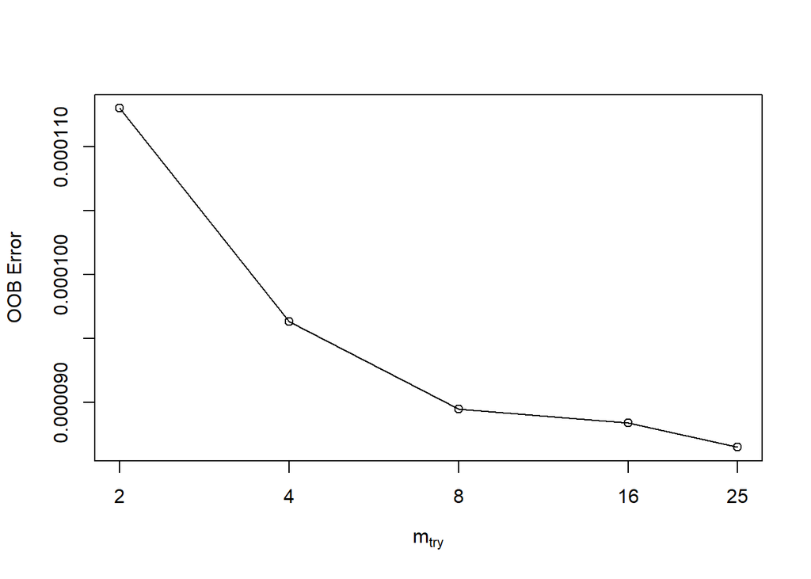

```
##
## Call:
##  randomForest(x = x, y = y, mtry = res[which.min(res[, 2]), 1],      nodesize = 50)
##                Type of random forest: regression
##                      Number of trees: 500
## No. of variables tried at each split: 25
##
##           Mean of squared residuals: 8.604318e-05
##                     % Var explained: 49.05
```

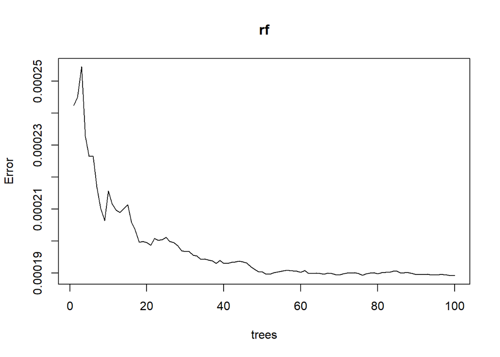

```r
rf = randomForest(KOnextday~.-KOupdown,
                      data=train.KOdata3,
                      ntree=100,
                      nodesize=50,
                      mtry=14)


plot(rf)
```

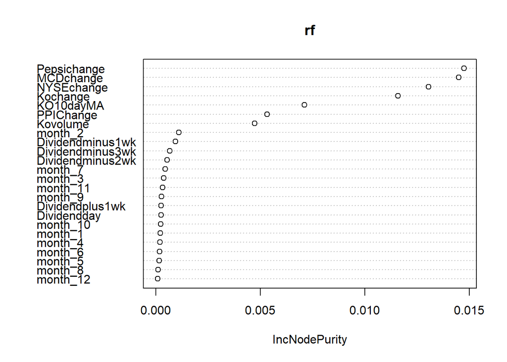

```r
varImpPlot(rf)
```

```r
mean = mean(train.KOdata3$KOnextday)
pred_rf = predict(rf, newdata=test.KOdata3)
SSE_rf = sum((test.KOdata3$KOnextday - pred_rf)^2)
SST_rf = sum((test.KOdata3$KOnextday - mean)^2)
OSR2_rf = 1 - SSE_rf/SST_rf
OSR2_rf
```

```
## [1] 0.01662649
```

### Artificial neural network

```r
str(KOdata4)
```

```
## 'data.frame':    1257 obs. of  25 variables:
##  $ KOnextday       : num  -0.00391 0.00175 0.00196 -0.01088 0.01034 ...
##  $ KOupdown        : int  0 1 1 0 1 1 1 1 1 1 ...
##  $ Kovolume        : num  -0.0891 0.0773 0.1769 -0.4313 0.5752 ...
##  $ Kochange        : num  0.00262 -0.00391 0.00175 0.00196 -0.01088 ...
##  $ Dividendday     : int  0 0 0 0 0 0 0 0 0 0 ...
##  $ Dividendminus1wk: int  0 0 0 0 0 0 0 0 0 0 ...
##  $ Dividendminus2wk: int  0 0 0 0 0 0 0 0 0 0 ...
##  $ Dividendminus3wk: int  0 0 0 0 0 0 1 1 1 1 ...
##  $ Dividendplus1wk : int  0 0 0 0 0 0 0 0 0 0 ...
##  $ NYSEchange      : num  0.01299 -0.00736 0.00706 0.00665 -0.00059 ...
##  $ Pepsichange     : num  0.00529 -0.000907 -0.000727 0.001545 -0.00871 ...
##  $ KO10dayMA       : num  39.4 39.3 39.3 39.2 39.1 ...
##  $ PPIChange       : num  0.002 0.002 0.002 0.002 0.002 0.002 0.002 0.002 0.002 0.002 ...
##  $ MCDchange       : num  0.00409 -0.00324 0.0104 0.00327 0.00842 ...
##  $ month_2         : int  0 0 0 0 0 0 0 0 0 0 ...
##  $ month_3         : int  0 0 0 0 0 0 0 0 0 0 ...
##  $ month_4         : int  0 0 0 0 0 0 0 0 0 0 ...
##  $ month_5         : int  0 0 0 0 0 0 0 0 0 0 ...
##  $ month_6         : int  0 0 0 0 0 0 0 0 0 0 ...
##  $ month_7         : int  0 0 0 0 0 0 0 0 0 0 ...
##  $ month_8         : int  0 0 0 0 0 0 0 0 0 0 ...
##  $ month_9         : int  0 0 0 0 0 0 0 0 0 0 ...
##  $ month_10        : int  1 0 0 0 0 0 0 0 0 0 ...
##  $ month_11        : int  0 1 1 1 1 1 1 1 1 1 ...
##  $ month_12        : int  0 0 0 0 0 0 0 0 0 0 ...
```

```r
set.seed(1, sample.kind="Rejection")
spl = sample(nrow(KOdata4), 0.8*nrow(KOdata4))
intermediate = KOdata4[spl,]
test = KOdata4[-spl,]

set.seed(1, sample.kind="Rejection")
spl2 = sample(nrow(intermediate), 2/3*nrow(intermediate))
train = intermediate[spl2,]
valid = intermediate[-spl2,]
```

```r
maxVals = apply(train, 2, max)
minVals = apply(train, 2, min)

#maxVals
#minVals
```

```r
scaled_train = as.data.frame(scale(train, center = minVals,
                                scale = maxVals - minVals))

scaled_valid = as.data.frame(scale(valid, center = minVals,
                                     scale = maxVals - minVals))

scaled_test = as.data.frame(scale(test, center = minVals,
                                     scale = maxVals - minVals))
```

#### The following code added for NN with Regression (NNR)

```r
KOdata5 = subset(KOdata2, select = -c(Date,year,month_1,KOupdown) )


set.seed(1, sample.kind="Rejection")
spl.nnr = sample(nrow(KOdata5), 0.8*nrow(KOdata5))
intermediate.nnr = KOdata5[spl.nnr,]
test.nnr = KOdata5[-spl.nnr,]

set.seed(1, sample.kind="Rejection")
spl2.nnr = sample(nrow(intermediate.nnr), 2/3*nrow(intermediate.nnr))
train.nnr = intermediate.nnr[spl2.nnr,]
valid.nnr = intermediate.nnr[-spl2.nnr,]
```

```r
maxVals.nnr = apply(train.nnr, 2, max)
minVals.nnr = apply(train.nnr, 2, min)

maxVals.nnr
```

```
##        KOnextday         Kovolume         Kochange      Dividendday
##       0.06309400       2.76767755       0.06479571       1.00000000
## Dividendminus1wk Dividendminus2wk Dividendminus3wk  Dividendplus1wk
##       1.00000000       1.00000000       1.00000000       1.00000000
##       NYSEchange      Pepsichange        KO10dayMA        PPIChange
##       0.04606466       0.10499400      64.52891540       0.05300000
##        MCDchange          month_2          month_3          month_4
##       0.10422235       1.00000000       1.00000000       1.00000000
##          month_5          month_6          month_7          month_8
##       1.00000000       1.00000000       1.00000000       1.00000000
##          month_9         month_10         month_11         month_12
##       1.00000000       1.00000000       1.00000000       1.00000000
```

```r
minVals.nnr
```

```
##        KOnextday         Kovolume         Kochange      Dividendday
##      -0.06733555      -0.73599801      -0.08438944       0.00000000
## Dividendminus1wk Dividendminus2wk Dividendminus3wk  Dividendplus1wk
##       0.00000000       0.00000000       0.00000000       0.00000000
##       NYSEchange      Pepsichange        KO10dayMA        PPIChange
##      -0.04115302      -0.11428316      36.40649180      -0.04800000
##        MCDchange          month_2          month_3          month_4
##      -0.06990931       0.00000000       0.00000000       0.00000000
##          month_5          month_6          month_7          month_8
##       0.00000000       0.00000000       0.00000000       0.00000000
##          month_9         month_10         month_11         month_12
##       0.00000000       0.00000000       0.00000000       0.00000000
```

```r
scaled_train.nnr = as.data.frame(scale(train.nnr, center = minVals.nnr,
                                scale = maxVals.nnr - minVals.nnr))

scaled_valid.nnr = as.data.frame(scale(valid.nnr, center = minVals.nnr,
                                     scale = maxVals.nnr - minVals.nnr))

scaled_test.nnr = as.data.frame(scale(test.nnr, center = minVals.nnr,
                                     scale = maxVals.nnr - minVals.nnr))
```

```r
set.seed(1, sample.kind="Rejection")
neural1 = neuralnet(KOupdown~Kovolume+Kochange+NYSEchange+Pepsichange+PPIChange+MCDchange+month_5, data = scaled_train, hidden=c(4), linear.output=F,threshold=0.005, stepmax=50000,lifesign='full', lifesign.step=500)
```

[output not shown]

[output cut: 41 more lines]

```r
plot(neural1)
```

```r
set.seed(2, sample.kind="Rejection")
neural2 = neuralnet(KOupdown~.-KOnextday, data = scaled_train, hidden=c(6), linear.output=T,threshold=0.01, stepmax=200000,lifesign='full', lifesign.step=500)
```

[output not shown]

[output cut: 154 more lines]

```r
plot(neural2)
```

```r
set.seed(1, sample.kind="Rejection")
neural3 = neuralnet(KOnextday~Kovolume+Kochange+NYSEchange+Pepsichange+PPIChange+MCDchange+month_5, data = scaled_train.nnr, hidden=c(4), linear.output=T,threshold=0.005, stepmax=50000,lifesign='full', lifesign.step=500)
```

[output not shown]

[output cut: 51 more lines]

```r
plot(neural3)
```

```r
set.seed(1, sample.kind="Rejection")
neural4 = neuralnet(KOnextday~.-KOupdown, data = scaled_train.nnr, hidden=c(7), linear.output=T,threshold=0.005, stepmax=200000,lifesign='full', lifesign.step=500)
```

[output not shown]

[output cut: 96 more lines]

```r
plot(neural4)
```

```r
pred.valid.neural4 = predict(neural4, newdata=scaled_valid.nnr)
summary(pred.valid.neural4)
```

```
##        V1
##  Min.   :-0.0948
##  1st Qu.: 0.4797
##  Median : 0.5192
##  Mean   : 0.5127
##  3rd Qu.: 0.5585
##  Max.   : 0.9309
```

```r
m = min(train.nnr$KOnextday)
M = max(train.nnr$KOnextday)

valid.pred.nn = (pred.valid.neural4 * (M - m)) + m

summary(valid.pred.nn)
```

```
##        V1
##  Min.   :-0.0797002
##  1st Qu.:-0.0047664
##  Median : 0.0003863
##  Mean   :-0.0004616
##  3rd Qu.: 0.0055092
##  Max.   : 0.0540753
```

```r
train.mean = mean(train.nnr$KOnextday)
SSE.valid = sum((valid.pred.nn - valid.nnr$KOnextday)^2)
SST.valid = sum((train.mean - valid.nnr$KOnextday)^2)

1 - SSE.valid/SST.valid
```

```
## [1] -0.8957044
```

```r
OSR1 = 1 - SSE.valid/SST.valid
```

```r
set.seed(1, sample.kind="Rejection")
neural5 = neuralnet(KOnextday~.-KOupdown, data = scaled_train.nnr, hidden=c(7), linear.output=T,threshold=0.5, stepmax=100000,lifesign='full', lifesign.step=500)
```

```
## hidden: 7    thresh: 0.5    rep: 1/1    steps:      95   error: 3.20152  time: 0.04 secs
```

```r
plot(neural5)
```

```r
pred.valid.neural5 = predict(neural5, newdata=scaled_valid.nnr)
m = min(train.nnr$KOnextday)
M = max(train.nnr$KOnextday)
valid.pred.nn = (pred.valid.neural5 * (M - m)) + m

train.mean = mean(train.nnr$KOnextday)
SSE.valid = sum((valid.pred.nn - valid.nnr$KOnextday)^2)
SST.valid = sum((train.mean - valid.nnr$KOnextday)^2)

1 - SSE.valid/SST.valid
```

```
## [1] -0.08085926
```

```r
OSR2 = 1 - SSE.valid/SST.valid
```

#### Tried various neural network models with various combinations of parameters to bring the OSR2 value down.

c(4,2) neural5 = neuralnet(KOnextday~.-KOupdown, data = scaled_train, hidden=c(4,2), linear.output=T,threshold=0.0025, stepmax=50000,lifesign=‘full’, lifesign.step=500) OSR2 = 1 - SSE.valid/SST.valid -4.907963

neural5 = neuralnet(KOnextday~.-KOupdown, data = scaled_train, hidden=c(9), linear.output=T,threshold=0.006, stepmax=100000,lifesign=‘full’, lifesign.step=500)

OSR2 = -1.411816

neural5 = neuralnet(KOnextday~.-KOupdown, data = scaled_train, hidden=c(10), linear.output=T,threshold=0.006, stepmax=100000,lifesign=‘full’, lifesign.step=500) Warning: Algorithm did not converge in 1 of 1 repetition(s) within the stepmax.

neural5 = neuralnet(KOnextday~.-KOupdown, data = scaled_train, hidden=c(8), linear.output=T,threshold=0.006, stepmax=100000,lifesign=‘full’, lifesign.step=500) Warning: Algorithm did not converge in 1 of 1 repetition(s) within the stepmax.

set.seed(1, sample.kind=“Rejection”) neural5 = neuralnet(KOnextday~.-KOupdown, data = scaled_train, hidden=c(7), linear.output=T,threshold=0.005, stepmax=100000,lifesign=‘full’, lifesign.step=500) OSR2 = -0.8957044

neural5 = neuralnet(KOnextday~.-KOupdown, data = scaled_train, hidden=c(6), linear.output=T,threshold=0.003, stepmax=100000,lifesign=‘full’, lifesign.step=500) OSR2 = -46.27811

neural5 = neuralnet(KOnextday~.-KOupdown, data = scaled_train, hidden=c(6), linear.output=T,threshold=0.001, stepmax=100000,lifesign=‘full’, lifesign.step=500) OSR2 = -56.02714

neural5 = neuralnet(KOnextday~.-KOupdown, data = scaled_train, hidden=c(7), linear.output=T,threshold=0.01, stepmax=100000,lifesign=‘full’, lifesign.step=500) OSR2 = -0.7478942

neural5 = neuralnet(KOnextday~.-KOupdown, data = scaled_train, hidden=c(7), linear.output=T,threshold=0.05, stepmax=100000,lifesign=‘full’, lifesign.step=500) OSR2 = -0.6676118

hidden=c(9) OSR2 = -0.6626675

=c(10) OSR2 = -0.9058829

neural5 = neuralnet(KOnextday~.-KOupdown, data = scaled_train, hidden=c(9), linear.output=T,threshold=0.07, stepmax=100000,lifesign=‘full’, lifesign.step=500) OSR2 = -0.6233809

neural5 = neuralnet(KOnextday~.-KOupdown, data = scaled_train, hidden=c(7), linear.output=T,threshold=0.07, stepmax=100000,lifesign=‘full’, lifesign.step=500) OSR2 = -0.6033476

neural5 = neuralnet(KOnextday~.-KOupdown, data = scaled_train, hidden=c(7), linear.output=T,threshold=0.1, stepmax=100000,lifesign=‘full’, lifesign.step=500) OSR2 = -0.5470808

neural5 = neuralnet(KOnextday~.-KOupdown, data = scaled_train, hidden=c(7), linear.output=T,threshold=0.5, stepmax=100000,lifesign=‘full’, lifesign.step=500) OSR2 = -0.08085926

0.6 OSR2 = -0.08401804

### Predicting October 28th Coco Cola’s price change by using regression tree:

```r
names(train.df)
```

```
##  [1] "KOnextday"        "Kovolume"         "Kochange"         "Dividendday"
##  [5] "Dividendminus1wk" "Dividendminus2wk" "Dividendminus3wk" "Dividendplus1wk"
##  [9] "NYSEchange"       "Pepsichange"      "KO10dayMA"        "PPIChange"
## [13] "MCDchange"        "month_2"          "month_3"          "month_4"
## [17] "month_5"          "month_6"          "month_7"          "month_8"
## [21] "month_9"          "month_10"         "month_11"         "month_12"
```

```r
xtrain.df = subset(train.df, select = -c(KOnextday) )
xtrain.df
```

[output not shown]

[output cut: 4009 more lines]

```r
obs.1028 = data.frame(Kovolume=-0.195755674, Kochange=0.020661817, Dividendday=0, Dividendminus1wk=0, Dividendminus2wk=0, Dividendminus3wk=0, Dividendplus1wk=0, NYSEchange=0.080999504, Pepsichange=0.018727588, KO10dayMA=57.5329995, PPIChange=0.005, MCDchange=0.035494696, month_2=0, month_3=0, month_4=0, month_5=0, month_6=0, month_7=0, month_8=0, month_9=0, month_10=1, month_11=0, month_12=0)

obs.1028 <- rbind(xtrain.df[1, ] , obs.1028)
obs.1028 <- obs.1028[-1,]
obs.1028
```

```
##     Kovolume   Kochange Dividendday Dividendminus1wk Dividendminus2wk
## 1 -0.1957557 0.02066182           0                0                0
##   Dividendminus3wk Dividendplus1wk NYSEchange Pepsichange KO10dayMA PPIChange
## 1                0               0  0.0809995  0.01872759    57.533     0.005
##   MCDchange month_2 month_3 month_4 month_5 month_6 month_7 month_8 month_9
## 1 0.0354947       0       0       0       0       0       0       0       0
##   month_10 month_11 month_12
## 1        1        0        0
```

```r
predict(optimal.tree.cv, newdata = obs.1028, type="vector")
```

```
##           1
## -0.03050487
```

The actual price change of KO is -0.01497695

### Predicting October 31 Coco Cola’s price change by using regression tree:

```r
xtrain.df
```

[output not shown]

[output cut: 4009 more lines]

```r
obs.1029 = data.frame(Kovolume=0.087478373, Kochange=-0.01497695, Dividendday=0, Dividendminus1wk=0, Dividendminus2wk=0, Dividendminus3wk=0, Dividendplus1wk=0, NYSEchange=-0.070407956, Pepsichange=-0.003566896, KO10dayMA=57.9068516, PPIChange=0.005, MCDchange=-0.006775443, month_2=0, month_3=0, month_4=0, month_5=0, month_6=0, month_7=0, month_8=0, month_9=0, month_10=1, month_11=0, month_12=0)

obs.1029 <- rbind(xtrain.df[1, ] , obs.1029)
obs.1029 <- obs.1029[-1,]
obs.1029
```

```
##     Kovolume    Kochange Dividendday Dividendminus1wk Dividendminus2wk
## 1 0.08747837 -0.01497695           0                0                0
##   Dividendminus3wk Dividendplus1wk  NYSEchange  Pepsichange KO10dayMA PPIChange
## 1                0               0 -0.07040796 -0.003566896  57.90685     0.005
##      MCDchange month_2 month_3 month_4 month_5 month_6 month_7 month_8 month_9
## 1 -0.006775443       0       0       0       0       0       0       0       0
##   month_10 month_11 month_12
## 1        1        0        0
```

```r
predict(optimal.tree.cv, newdata = obs.1029, type="vector")
```

```
##          1
## 0.00165104
```

The actual price change of KO is -0.003508736